# How to get most value out of your rent out property in Seattle?

*Understand lodging services in Seattle using Airbnb data.*

### Business Understanding

Airbnb is one of the most popular marketplaces for offering lodging and homestay services. If I’m a homeowner in Seattle, how can I get the most value out of my rent-out property?  
I’m interested in answering the following three questions.

1. What are the most important features that estimate the rental price?
2. What top amenities should I offer in my rent-out place?
3. What are the most requested neighborhoods in Seattle?

### Data Understanding

```python
#import libraries
import numpy as np
import pandas as pd
import matplotlib.pyplot as plt
import seaborn as sns

from datetime import date
from datetime import datetime

from sklearn.preprocessing import MultiLabelBinarizer
from sklearn.preprocessing import MinMaxScaler
```

```python
listings = pd.read_csv('data/listings.csv')
calendar = pd.read_csv('data/calendar.csv')
reviews = pd.read_csv('data/reviews.csv')
```

**Listings dataset**

This dataset contains descriptions and review scores of the listings.

```python
print(listings.shape)
listings.head()
```

```
(3818, 92)
```

|  | id | listing_url | scrape_id | last_scraped | name | summary | space | description | experiences_offered | neighborhood_overview | ... | review_scores_value | requires_license | license | jurisdiction_names | instant_bookable | cancellation_policy | require_guest_profile_picture | require_guest_phone_verification | calculated_host_listings_count | reviews_per_month |
| --- | --- | --- | --- | --- | --- | --- | --- | --- | --- | --- | --- | --- | --- | --- | --- | --- | --- | --- | --- | --- | --- |
| 0 | 241032 | https://www.airbnb.com/rooms/241032 | 20160104002432 | 2016-01-04 | Stylish Queen Anne Apartment | NaN | Make your self at home in this charming one-be... | Make your self at home in this charming one-be... | none | NaN | ... | 10.0 | f | NaN | WASHINGTON | f | moderate | f | f | 2 | 4.07 |
| 1 | 953595 | https://www.airbnb.com/rooms/953595 | 20160104002432 | 2016-01-04 | Bright & Airy Queen Anne Apartment | Chemically sensitive? We've removed the irrita... | Beautiful, hypoallergenic apartment in an extr... | Chemically sensitive? We've removed the irrita... | none | Queen Anne is a wonderful, truly functional vi... | ... | 10.0 | f | NaN | WASHINGTON | f | strict | t | t | 6 | 1.48 |
| 2 | 3308979 | https://www.airbnb.com/rooms/3308979 | 20160104002432 | 2016-01-04 | New Modern House-Amazing water view | New modern house built in 2013. Spectacular s... | Our house is modern, light and fresh with a wa... | New modern house built in 2013. Spectacular s... | none | Upper Queen Anne is a charming neighborhood fu... | ... | 10.0 | f | NaN | WASHINGTON | f | strict | f | f | 2 | 1.15 |
| 3 | 7421966 | https://www.airbnb.com/rooms/7421966 | 20160104002432 | 2016-01-04 | Queen Anne Chateau | A charming apartment that sits atop Queen Anne... | NaN | A charming apartment that sits atop Queen Anne... | none | NaN | ... | NaN | f | NaN | WASHINGTON | f | flexible | f | f | 1 | NaN |
| 4 | 278830 | https://www.airbnb.com/rooms/278830 | 20160104002432 | 2016-01-04 | Charming craftsman 3 bdm house | Cozy family craftman house in beautiful neighb... | Cozy family craftman house in beautiful neighb... | Cozy family craftman house in beautiful neighb... | none | We are in the beautiful neighborhood of Queen ... | ... | 9.0 | f | NaN | WASHINGTON | f | strict | f | f | 1 | 0.89 |

5 rows × 92 columns

```python
listings.info()
```

```
<class 'pandas.core.frame.DataFrame'>
RangeIndex: 3818 entries, 0 to 3817
Data columns (total 92 columns):
id                                  3818 non-null int64
listing_url                         3818 non-null object
scrape_id                           3818 non-null int64
last_scraped                        3818 non-null object
name                                3818 non-null object
summary                             3641 non-null object
space                               3249 non-null object
description                         3818 non-null object
experiences_offered                 3818 non-null object
neighborhood_overview               2786 non-null object
notes                               2212 non-null object
transit                             2884 non-null object
thumbnail_url                       3498 non-null object
medium_url                          3498 non-null object
picture_url                         3818 non-null object
xl_picture_url                      3498 non-null object
host_id                             3818 non-null int64
host_url                            3818 non-null object
host_name                           3816 non-null object
host_since                          3816 non-null object
host_location                       3810 non-null object
host_about                          2959 non-null object
host_response_time                  3295 non-null object
host_response_rate                  3295 non-null object
host_acceptance_rate                3045 non-null object
host_is_superhost                   3816 non-null object
host_thumbnail_url                  3816 non-null object
host_picture_url                    3816 non-null object
host_neighbourhood                  3518 non-null object
host_listings_count                 3816 non-null float64
host_total_listings_count           3816 non-null float64
host_verifications                  3818 non-null object
host_has_profile_pic                3816 non-null object
host_identity_verified              3816 non-null object
street                              3818 non-null object
neighbourhood                       3402 non-null object
neighbourhood_cleansed              3818 non-null object
```

[output cut: 42 more lines]

```
review_scores_checkin               3160 non-null float64
review_scores_communication         3167 non-null float64
review_scores_location              3163 non-null float64
review_scores_value                 3162 non-null float64
requires_license                    3818 non-null object
license                             0 non-null float64
jurisdiction_names                  3818 non-null object
instant_bookable                    3818 non-null object
cancellation_policy                 3818 non-null object
require_guest_profile_picture       3818 non-null object
require_guest_phone_verification    3818 non-null object
calculated_host_listings_count      3818 non-null int64
reviews_per_month                   3191 non-null float64
dtypes: float64(17), int64(13), object(62)
memory usage: 2.7+ MB
```

**Calendar dataset**

This dataset hold the listing price and availablility on a particular date.

```python
print(calendar.shape)
calendar.head()
```

```
(1393570, 4)
```

|  | listing_id | date | available | price |
| --- | --- | --- | --- | --- |
| 0 | 241032 | 2016-01-04 | t | $85.00 |
| 1 | 241032 | 2016-01-05 | t | $85.00 |
| 2 | 241032 | 2016-01-06 | f | NaN |
| 3 | 241032 | 2016-01-07 | f | NaN |
| 4 | 241032 | 2016-01-08 | f | NaN |

```python
calendar.info()
```

```
<class 'pandas.core.frame.DataFrame'>
RangeIndex: 1393570 entries, 0 to 1393569
Data columns (total 4 columns):
listing_id    1393570 non-null int64
date          1393570 non-null object
available     1393570 non-null object
price         934542 non-null object
dtypes: int64(1), object(3)
memory usage: 42.5+ MB
```

**Reviews dataset**

This dataset contains review comments along with reviewer and listing identifier information.

```python
print(reviews.shape)
reviews.head()
```

```
(84849, 6)
```

|  | listing_id | id | date | reviewer_id | reviewer_name | comments |
| --- | --- | --- | --- | --- | --- | --- |
| 0 | 7202016 | 38917982 | 2015-07-19 | 28943674 | Bianca | Cute and cozy place. Perfect location to every... |
| 1 | 7202016 | 39087409 | 2015-07-20 | 32440555 | Frank | Kelly has a great room in a very central locat... |
| 2 | 7202016 | 39820030 | 2015-07-26 | 37722850 | Ian | Very spacious apartment, and in a great neighb... |
| 3 | 7202016 | 40813543 | 2015-08-02 | 33671805 | George | Close to Seattle Center and all it has to offe... |
| 4 | 7202016 | 41986501 | 2015-08-10 | 34959538 | Ming | Kelly was a great host and very accommodating ... |

```python
reviews.info()
```

```
<class 'pandas.core.frame.DataFrame'>
RangeIndex: 84849 entries, 0 to 84848
Data columns (total 6 columns):
listing_id       84849 non-null int64
id               84849 non-null int64
date             84849 non-null object
reviewer_id      84849 non-null int64
reviewer_name    84849 non-null object
comments         84831 non-null object
dtypes: int64(3), object(3)
memory usage: 3.9+ MB
```

- 'listings' dataset has a lot of missing values and it requires signifant data cleaning.
- After taking a look at the data attributes, I think we can answer our questions from the 'listings' dataset.
- 'calendar' dataset has some missing values in the 'price' column. If required, we may use that dataset to see if there are any seasonal spikes in price.
- 'reviews' dataset has only a few missing values but its key content is unstructured data. We may use it for qualitative analysis if there is not enough information in other datasets to answer our questions.

**Data Preparation**

```python
listings_copy = listings.copy(deep=True)
```

```python
listings = listings_copy.copy(deep=True)
```

```python
listings_columns = listings.columns
```

```python
listings.shape
```

```
(3818, 92)
```

We have 92 columns in listings dataset.

**Missing data**

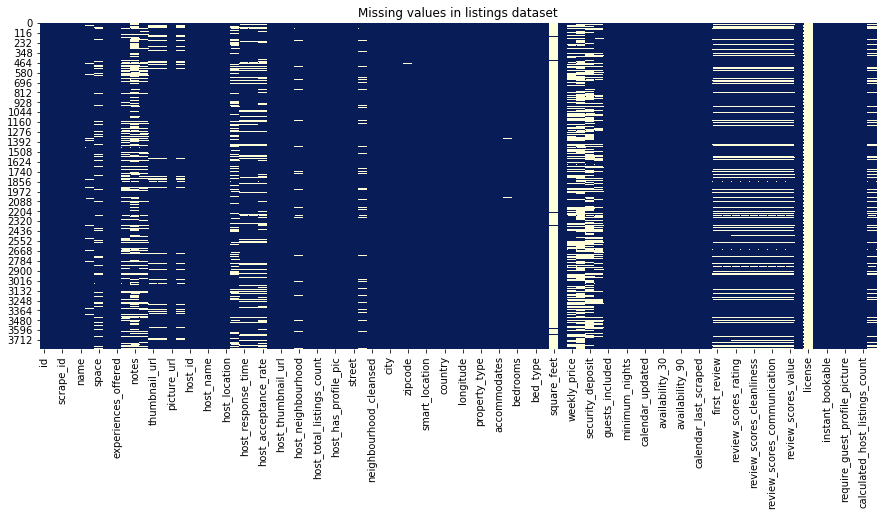

```python
plt.figure(figsize=(15,6));
sns.heatmap(~listings.isnull(), cmap='YlGnBu', cbar=False);
plt.title('Missing values in listings dataset');
plt.show()
```

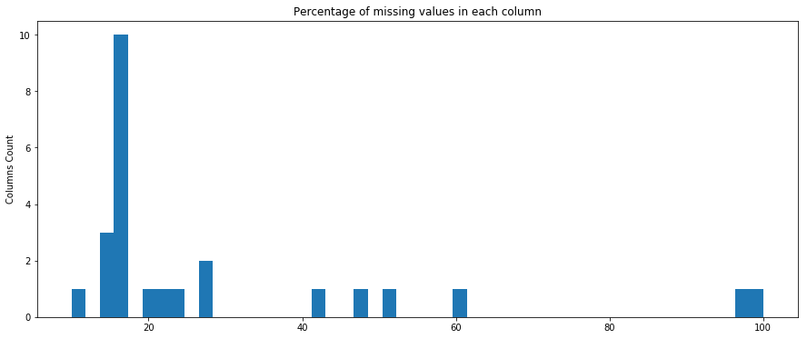

```python
missing_count = listings.isnull().sum()
missing_percentage = missing_count / len(listings) * 100

plt.figure(figsize=(15,6))
plt.hist(missing_percentage, bins=np.linspace(10, 100, 50))
plt.ylabel('Columns Count')
plt.title('Percentage of missing values in each column');
plt.show()
```

*Lets drop the columns with high number of missing values*

```python
cols_to_drop = missing_percentage[missing_percentage > 50].index
len(cols_to_drop)
```

```
4
```

```python
cols_to_drop
```

```
Index(['square_feet', 'monthly_price', 'security_deposit', 'license'], dtype='object')
```

```python
listings.drop(cols_to_drop, axis=1, inplace=True)
```

*Lets drop the irrelevant columns*

```python
irrelevant_columns = ['calendar_last_scraped','city','country','country_code','description','experiences_offered',
                      'first_review','host_about','host_id','host_location','host_name','host_neighbourhood',
                      'host_picture_url','host_thumbnail_url','host_url','host_verifications','id',
                      'last_review','last_scraped','listing_url','market','medium_url','name','neighborhood_overview',
                      'neighbourhood','notes','picture_url','scrape_id','smart_location','space','state','street','summary',
                      'thumbnail_url','transit', 'weekly_price','xl_picture_url']

len(irrelevant_columns)
```

```
37
```

```python
listings.drop(irrelevant_columns, axis=1, inplace=True)
listings.shape
```

```
(3818, 51)
```

*Investigate 'price' column*

```python
listings['price'].describe()
```

```
count        3818
unique        273
top       $150.00
freq          162
Name: price, dtype: object
```

```python
# Convert price to numeric column
listings['price'] = listings['price'].apply(lambda x: float(x[1:].replace(',', '')))
listings['price'].describe()
```

```
count    3818.000000
mean      127.976166
std        90.250022
min        20.000000
25%        75.000000
50%       100.000000
75%       150.000000
max      1000.000000
Name: price, dtype: float64
```

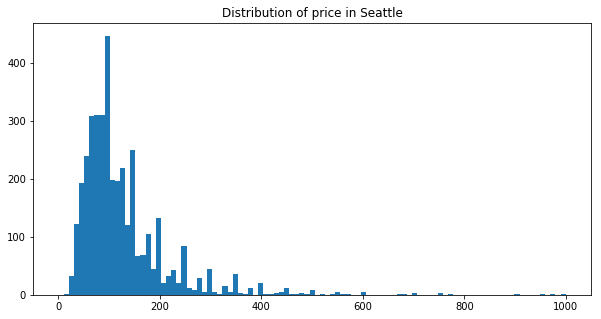

```python
plt.figure(figsize=(10, 5));
plt.hist(listings['price'], bins=np.linspace(0,1000,100));
plt.title('Distribution of price in Seattle');
plt.show()
```

```python
listings['price'].median()
```

```
100.0
```

**The median value is 100 and the third quartile is 150. Almost 98% of data lie below 400.**

```python
listings[listings['price']>400].shape[0]/len(listings)*100
```

```
1.650078575170246
```

Lets drop the rows with price value above 400.

```python
listings = listings[listings['price']<=400]
```

```python
listings.shape
```

```
(3755, 51)
```

*Convert 'host_since' column to a meaningful numeric value*

```python
listings = listings[~listings['host_since'].isnull()]
```

```python
current_time = datetime.strptime('2019-06-20','%Y-%m-%d')
current_time
```

```
datetime.datetime(2019, 6, 20, 0, 0)
```

```python
listings['host_since'] = listings['host_since'].apply(lambda x: (current_time - datetime.strptime(x, '%Y-%m-%d')).days)
listings['host_since'].describe()
```

```
count    3753.000000
mean     2100.196376
std       570.195727
min      1264.000000
25%      1618.000000
50%      2016.000000
75%      2500.000000
max      3874.000000
Name: host_since, dtype: float64
```

*Lets process the 'amenities' column*

```python
listings_2 = listings.copy(deep=True)
```

```python
listings_2['amenities'].head()
```

```
0    {TV,"Cable TV",Internet,"Wireless Internet","A...
1    {TV,Internet,"Wireless Internet",Kitchen,"Free...
3    {Internet,"Wireless Internet",Kitchen,"Indoor ...
5    {"Wireless Internet","Free Parking on Premises...
6    {"Wireless Internet","Free Parking on Premises...
Name: amenities, dtype: object
```

```python
listings_2['amenities_temp'] = listings_2['amenities'].apply(lambda x: x.replace('{', '').replace('}', '').replace('"', ''))
```

```python
listings_2['amenities_temp'].head()
```

```
0    TV,Cable TV,Internet,Wireless Internet,Air Con...
1    TV,Internet,Wireless Internet,Kitchen,Free Par...
3    Internet,Wireless Internet,Kitchen,Indoor Fire...
5    Wireless Internet,Free Parking on Premises,Hea...
6    Wireless Internet,Free Parking on Premises,Hea...
Name: amenities_temp, dtype: object
```

```python
listing_amenities= listings_2['amenities_temp'].map(lambda x: [amenity for amenity in x.split(',')])
```

```python
listings_2['amenities'] = listing_amenities
```

```python
all_amenities = set([item for item_list in listing_amenities for item in item_list if len(item)>1])
all_amenities = list(all_amenities)
len(all_amenities)
```

```
41
```

**We have 41 total possible amenities.**

```python
mlb = MultiLabelBinarizer()
amenities_binarized = pd.DataFrame(mlb.fit_transform(listings_2['amenities']), columns=mlb.classes_, index=listings_2.index)
listings_3 = pd.concat([listings_2, amenities_binarized], axis=1, sort=False)
listings_3.drop(['amenities'], axis=1, inplace=True)
```

```python
listings_3.shape
```

```
(3753, 93)
```

```python
listings_3.head()
```

|  | host_since | host_response_time | host_response_rate | host_acceptance_rate | host_is_superhost | host_listings_count | host_total_listings_count | host_has_profile_pic | host_identity_verified | neighbourhood_cleansed | ... | Safety Card | Shampoo | Smoke Detector | Smoking Allowed | Suitable for Events | TV | Washer | Washer / Dryer | Wheelchair Accessible | Wireless Internet |
| --- | --- | --- | --- | --- | --- | --- | --- | --- | --- | --- | --- | --- | --- | --- | --- | --- | --- | --- | --- | --- | --- |
| 0 | 2870 | within a few hours | 96% | 100% | f | 3.0 | 3.0 | t | t | West Queen Anne | ... | 0 | 0 | 0 | 0 | 0 | 1 | 1 | 0 | 0 | 1 |
| 1 | 2310 | within an hour | 98% | 100% | t | 6.0 | 6.0 | t | t | West Queen Anne | ... | 1 | 0 | 1 | 0 | 0 | 1 | 1 | 0 | 0 | 1 |
| 3 | 2052 | NaN | NaN | NaN | f | 1.0 | 1.0 | t | t | West Queen Anne | ... | 1 | 1 | 1 | 0 | 0 | 0 | 1 | 0 | 0 | 1 |
| 5 | 3099 | NaN | NaN | NaN | f | 1.0 | 1.0 | t | t | West Queen Anne | ... | 0 | 1 | 1 | 0 | 0 | 0 | 0 | 0 | 0 | 1 |
| 6 | 2577 | within an hour | 100% | 100% | t | 1.0 | 1.0 | t | t | West Queen Anne | ... | 0 | 1 | 1 | 0 | 0 | 0 | 0 | 0 | 0 | 1 |

5 rows × 93 columns

```python
listings = listings_3.copy(deep=True)
```

```python
listings.drop(['', 'amenities_temp'], axis=1, inplace=True)
```

```python
listings.columns
```

```
Index(['host_since', 'host_response_time', 'host_response_rate',
       'host_acceptance_rate', 'host_is_superhost', 'host_listings_count',
       'host_total_listings_count', 'host_has_profile_pic',
       'host_identity_verified', 'neighbourhood_cleansed',
       'neighbourhood_group_cleansed', 'zipcode', 'latitude', 'longitude',
       'is_location_exact', 'property_type', 'room_type', 'accommodates',
       'bathrooms', 'bedrooms', 'beds', 'bed_type', 'price', 'cleaning_fee',
       'guests_included', 'extra_people', 'minimum_nights', 'maximum_nights',
       'calendar_updated', 'has_availability', 'availability_30',
       'availability_60', 'availability_90', 'availability_365',
       'number_of_reviews', 'review_scores_rating', 'review_scores_accuracy',
       'review_scores_cleanliness', 'review_scores_checkin',
       'review_scores_communication', 'review_scores_location',
       'review_scores_value', 'requires_license', 'jurisdiction_names',
       'instant_bookable', 'cancellation_policy',
       'require_guest_profile_picture', 'require_guest_phone_verification',
       'calculated_host_listings_count', 'reviews_per_month',
       '24-Hour Check-in', 'Air Conditioning', 'Breakfast',
       'Buzzer/Wireless Intercom', 'Cable TV', 'Carbon Monoxide Detector',
       'Cat(s)', 'Dog(s)', 'Doorman', 'Dryer', 'Elevator in Building',
       'Essentials', 'Family/Kid Friendly', 'Fire Extinguisher',
       'First Aid Kit', 'Free Parking on Premises', 'Gym', 'Hair Dryer',
       'Hangers', 'Heating', 'Hot Tub', 'Indoor Fireplace', 'Internet', 'Iron',
       'Kitchen', 'Laptop Friendly Workspace', 'Lock on Bedroom Door',
       'Other pet(s)', 'Pets Allowed', 'Pets live on this property', 'Pool',
       'Safety Card', 'Shampoo', 'Smoke Detector', 'Smoking Allowed',
       'Suitable for Events', 'TV', 'Washer', 'Washer / Dryer',
       'Wheelchair Accessible', 'Wireless Internet'],
      dtype='object')
```

**Convert other object columns to the right numeric value**

```python
data_types = listings.dtypes
```

```python
obj_types = data_types[data_types == 'object']
obj_types
```

```
host_response_time                  object
host_response_rate                  object
host_acceptance_rate                object
host_is_superhost                   object
host_has_profile_pic                object
host_identity_verified              object
neighbourhood_cleansed              object
neighbourhood_group_cleansed        object
zipcode                             object
is_location_exact                   object
property_type                       object
room_type                           object
bed_type                            object
cleaning_fee                        object
extra_people                        object
calendar_updated                    object
has_availability                    object
requires_license                    object
jurisdiction_names                  object
instant_bookable                    object
cancellation_policy                 object
require_guest_profile_picture       object
require_guest_phone_verification    object
dtype: object
```

```python
listings[['cleaning_fee', 'extra_people', 'host_response_rate']].head()
```

|  | cleaning_fee | extra_people | host_response_rate |
| --- | --- | --- | --- |
| 0 | NaN | $5.00 | 96% |
| 1 | $40.00 | $0.00 | 98% |
| 3 | NaN | $0.00 | NaN |
| 5 | $40.00 | $30.00 | NaN |
| 6 | NaN | $10.00 | 100% |

```python
listings['cleaning_fee'] = listings['cleaning_fee'].replace( '[$,]','', regex=True ).astype(float)
listings['extra_people'] = listings['extra_people'].replace( '[$,]','', regex=True ).astype(float)
listings['host_response_rate'] = listings['host_response_rate'].replace( '%','', regex=True ).astype(float)
```

```python
listings[['cleaning_fee', 'extra_people', 'host_response_rate']].head()
```

|  | cleaning_fee | extra_people | host_response_rate |
| --- | --- | --- | --- |
| 0 | NaN | 5.0 | 96.0 |
| 1 | 40.0 | 0.0 | 98.0 |
| 3 | NaN | 0.0 | NaN |
| 5 | 40.0 | 30.0 | NaN |
| 6 | NaN | 10.0 | 100.0 |

**Fill missing values**

```python
# Fill 0
listings['cleaning_fee'].fillna(0, inplace = True)

# Fill median value
listings['bathrooms'].fillna(listings.groupby("bedrooms")["bathrooms"].transform("median"), inplace=True)
listings['beds'].fillna(listings.groupby("bedrooms")["beds"].transform("median"), inplace=True)
listings['bedrooms'].fillna(listings.groupby("bathrooms")["bedrooms"].transform("median"), inplace=True)
```

```python
# Fill mean value
review_cols = ['review_scores_rating', 'review_scores_accuracy', 'review_scores_cleanliness', 'review_scores_checkin',
               'review_scores_communication', 'review_scores_location', 'review_scores_value', 'reviews_per_month']

for col in review_cols:
    listings[col].fillna(listings[col].mean(), inplace=True)

listings['host_response_rate'].fillna(listings['host_response_rate'].mean(), inplace = True)
```

```python
missing_count = listings.isnull().sum()

missing_count[missing_count != 0]
```

```
host_response_time      509
host_acceptance_rate    747
zipcode                   7
property_type             1
dtype: int64
```

**One-Hot Encoding**

```python
data_types = listings.dtypes
obj_types = data_types[data_types == 'object']
obj_types = list(obj_types.index)
obj_types
```

```
['host_response_time',
 'host_acceptance_rate',
 'host_is_superhost',
 'host_has_profile_pic',
 'host_identity_verified',
 'neighbourhood_cleansed',
 'neighbourhood_group_cleansed',
 'zipcode',
 'is_location_exact',
 'property_type',
 'room_type',
 'bed_type',
 'calendar_updated',
 'has_availability',
 'requires_license',
 'jurisdiction_names',
 'instant_bookable',
 'cancellation_policy',
 'require_guest_profile_picture',
 'require_guest_phone_verification']
```

```python
listings = pd.get_dummies(listings, columns=obj_types)
```

```python
price_target = listings['price']
listings.drop(['price'], axis=1, inplace=True)
```

**Normalization using MinMaxScaler**

```python
num_cols = ['host_since', 'latitude', 'longitude', 'review_scores_rating']
minmax_scaler = MinMaxScaler()
listings[num_cols] = minmax_scaler.fit_transform(listings[num_cols])
```

```python
listings.shape
```

```
(3753, 286)
```

```python
listings.columns
```

```
Index(['host_since', 'host_response_rate', 'host_listings_count',
       'host_total_listings_count', 'latitude', 'longitude', 'accommodates',
       'bathrooms', 'bedrooms', 'beds',
       ...
       'jurisdiction_names_WASHINGTON', 'instant_bookable_f',
       'instant_bookable_t', 'cancellation_policy_flexible',
       'cancellation_policy_moderate', 'cancellation_policy_strict',
       'require_guest_profile_picture_f', 'require_guest_profile_picture_t',
       'require_guest_phone_verification_f',
       'require_guest_phone_verification_t'],
      dtype='object', length=286)
```

### Modeling

**Split data into train and test sets**

```python
from sklearn.model_selection import train_test_split
from sklearn.ensemble import AdaBoostRegressor
from sklearn.model_selection import GridSearchCV

from sklearn.metrics import mean_squared_error
```

```python
X_train, X_test, y_train, y_test = train_test_split(listings, price_target, test_size = 0.2, random_state = 42)
```

```python
print("Training set size {}".format(X_train.shape[0]))
print("Testing set size {}".format(X_test.shape[0]))
```

```
Training set size 3002
Testing set size 751
```

```python
# Grid Search to find the best parameters
param_grid = {
    'n_estimators': [100, 200],
     'learning_rate' : [0.05,0.1],
     'loss': ['linear', 'square']
}

adaboost_regressor = AdaBoostRegressor(random_state=42)

grid_search_cv = GridSearchCV(adaboost_regressor, param_grid=param_grid, cv=5,
                             scoring='neg_mean_squared_error', return_train_score=True)
```

```python
grid_search_cv.fit(X_train, y_train)
```

```
GridSearchCV(cv=5, error_score='raise',
       estimator=AdaBoostRegressor(base_estimator=None, learning_rate=1.0, loss='linear',
         n_estimators=50, random_state=42),
       fit_params=None, iid=True, n_jobs=1,
       param_grid={'n_estimators': [100, 200], 'learning_rate': [0.05, 0.1], 'loss': ['linear', 'square']},
       pre_dispatch='2*n_jobs', refit=True, return_train_score=True,
       scoring='neg_mean_squared_error', verbose=0)
```

```python
grid_search_cv.best_params_
```

```
{'learning_rate': 0.05, 'loss': 'linear', 'n_estimators': 100}
```

```python
results = grid_search_cv.cv_results_
for mean_score, params in zip(results["mean_test_score"], results["params"]):
    print(np.sqrt(-mean_score), params)
```

```
46.052964146 {'learning_rate': 0.05, 'loss': 'linear', 'n_estimators': 100}
47.0030913424 {'learning_rate': 0.05, 'loss': 'linear', 'n_estimators': 200}
46.6343254657 {'learning_rate': 0.05, 'loss': 'square', 'n_estimators': 100}
48.6405182964 {'learning_rate': 0.05, 'loss': 'square', 'n_estimators': 200}
46.8592842523 {'learning_rate': 0.1, 'loss': 'linear', 'n_estimators': 100}
49.0450512876 {'learning_rate': 0.1, 'loss': 'linear', 'n_estimators': 200}
48.7598655769 {'learning_rate': 0.1, 'loss': 'square', 'n_estimators': 100}
50.7649210857 {'learning_rate': 0.1, 'loss': 'square', 'n_estimators': 200}
```

**Evaluation**

```python
y_pred = grid_search_cv.predict(X_test)
print("Error on Test Data: {0:.2f}".format(np.sqrt(mean_squared_error(y_test, y_pred))))
```

```
Error on Test Data: 42.95
```

## Question 1. What are the most important features that estimate the rental price?

```python
# Feature Importance
feature_importances = grid_search_cv.best_estimator_.feature_importances_
```

```python
feature_importances = sorted(zip(feature_importances, listings.columns), reverse=True)
```

```python
features, coefficients = [], []
for feature in feature_importances:
    features.append(feature[1])
    coefficients.append(feature[0])
```

```python
feature_importance_df = pd.DataFrame(columns=['feature', 'coefficients'])
feature_importance_df['feature'] = pd.Series(features)
feature_importance_df['coefficients'] = pd.Series(coefficients)
```

```python
feature_importance_df.sort_values(by=['coefficients'],ascending=False, inplace=True)
feature_importance_df.index = feature_importance_df['feature']
```

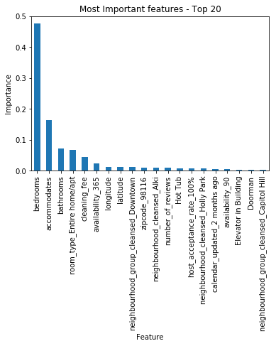

```python
plt.figure(figsize=(15,5));
feature_importance_df[:20].plot(kind='bar', legend=False);
plt.xlabel('Feature');
plt.ylabel('Importance');
plt.title('Most Important features - Top 20');
plt.xticks(rotation=90);
plt.show();
```

## Question 2. What top amenities should I offer in my rent-out place?

```python
# Amenity importance

amenities, coefficients = [], []
for feature in feature_importances:
    if feature[1] in all_amenities:
        amenities.append(feature[1])
        coefficients.append(feature[0])

amenity_importance_df = pd.DataFrame(columns=['amenity', 'coefficients'])
amenity_importance_df['amenity'] = pd.Series(amenities)
amenity_importance_df['coefficients'] = pd.Series(coefficients)

amenity_importance_df.sort_values(by=['coefficients'],ascending=False, inplace=True)
amenity_importance_df.index = amenity_importance_df['amenity']
```

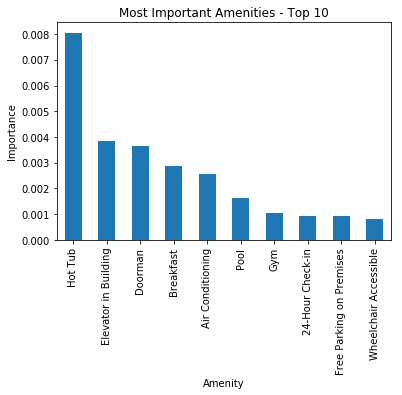

```python
plt.figure(figsize=(15,5));
amenity_importance_df[:10].plot(kind='bar', legend=False);
plt.xlabel('Amenity');
plt.ylabel('Importance');
plt.title('Most Important Amenities - Top 10');
plt.xticks(rotation=90);
plt.show();
```

## Question 3. What are the most requested neighborhoods in Seattle?

```python
listings = pd.read_csv('data/listings.csv')
print(list(listings.columns))
```

```
['id', 'listing_url', 'scrape_id', 'last_scraped', 'name', 'summary', 'space', 'description', 'experiences_offered', 'neighborhood_overview', 'notes', 'transit', 'thumbnail_url', 'medium_url', 'picture_url', 'xl_picture_url', 'host_id', 'host_url', 'host_name', 'host_since', 'host_location', 'host_a…
```

**We can answer this question with the columns 'neighbourhood', 'city' and 'state'**

```python
listings_loc_info = listings[['neighbourhood', 'city', 'state']]
listings_loc_info.head()
```

|  | neighbourhood | city | state |
| --- | --- | --- | --- |
| 0 | Queen Anne | Seattle | WA |
| 1 | Queen Anne | Seattle | WA |
| 2 | Queen Anne | Seattle | WA |
| 3 | Queen Anne | Seattle | WA |
| 4 | Queen Anne | Seattle | WA |

**Data Cleaning**

```python
listings_loc_info['state'].value_counts()
```

```
WA    3817
wa       1
Name: state, dtype: int64
```

```python
listings_loc_info[listings_loc_info['state']=='wa']
```

|  | neighbourhood | city | state |
| --- | --- | --- | --- |
| 3117 | NaN | seattle | wa |

Lets drop this row.

```python
listings_loc_info = listings_loc_info[listings_loc_info['state']!='wa']
```

```python
listings_loc_info['city'].value_counts()
```

```
Seattle                  3810
Seattle                     2
West Seattle                2
西雅图                         1
Phinney Ridge Seattle       1
Ballard, Seattle            1
Name: city, dtype: int64
```

All locations are in Seattle, except one and lets drop that item too.

```python
filter_condition = listings_loc_info['city'].apply(lambda x: True if 'Seattle' in x else False)

listings_loc_info = listings_loc_info[filter_condition]
```

```python
listings_loc_info['neighbourhood'].unique()
```

```
array(['Queen Anne', nan, 'Ballard', 'Phinney Ridge', 'Fremont',
       'Lower Queen Anne', 'Westlake', 'Wallingford', 'Green Lake',
       'Minor', 'Madrona', 'Harrison/Denny-Blaine', 'Leschi',
       'University District', 'Roosevelt', 'Madison Park', 'Capitol Hill',
       'Atlantic', 'North Beacon Hill', 'Central Business District',
       'Pike Place Market', 'Pike Market', 'Eastlake', 'Portage Bay',
       'South Lake Union', 'Magnolia', 'Belltown',
       'International District', 'Yesler Terrace', 'First Hill',
       'Pioneer Square', 'Gatewood', 'The Junction', 'Arbor Heights',
       'Alki', 'North Admiral', 'Crown Hill', 'Genesee', 'Fairmount Park',
       'Interbay', 'Industrial District', 'Holly Park',
       'South Beacon Hill', 'Greenwood', 'Bitter Lake', 'Fauntleroy',
       'Mount Baker', 'Columbia City', 'Seward Park', 'Brighton',
       'South Delridge', 'Highland Park', 'High Point', 'View Ridge',
       'Windermere', 'Dunlap', 'Rainier Beach', 'North Delridge',
       'Maple Leaf', 'Bryant', 'Ravenna', 'Wedgewood', 'Riverview',
       'Montlake', 'Broadway', 'Stevens', 'Victory Heights',
       'Mathews Beach', 'Cedar Park', 'Meadowbrook', 'Olympic Hills',
       'North Beach/Blue Ridge', 'Broadview', 'Haller Lake', 'Pinehurst',
       'Licton Springs', 'North College Park', 'Laurelhurst', 'Seaview',
       'Georgetown', 'South Park', 'Roxhill'], dtype=object)
```

```python
neighbourhood_counts = listings_loc_info['neighbourhood'].value_counts()
```

```python
# top 10
neighbourhood_counts[:10]
```

```
Capitol Hill           351
Ballard                213
Belltown               204
Minor                  192
Queen Anne             187
Fremont                148
Wallingford            143
University District    107
First Hill             105
Stevens                 98
Name: neighbourhood, dtype: int64
```

```python
neighbourhood_requests = pd.DataFrame(columns=['neighbourhood', 'count', 'percentage'])
neighbourhood_requests['neighbourhood'] = neighbourhood_counts.index
neighbourhood_requests['count'] = neighbourhood_counts.values
neighbourhood_requests['percentage'] = neighbourhood_requests['count'] / neighbourhood_counts.sum() * 100
neighbourhood_requests.index = neighbourhood_requests['neighbourhood']

neighbourhood_requests.head(10)
```

| neighbourhood | neighbourhood | count | percentage |
| --- | --- | --- | --- |
| Capitol Hill | Capitol Hill | 351 | 10.317460 |
| Ballard | Ballard | 213 | 6.261023 |
| Belltown | Belltown | 204 | 5.996473 |
| Minor | Minor | 192 | 5.643739 |
| Queen Anne | Queen Anne | 187 | 5.496767 |
| Fremont | Fremont | 148 | 4.350382 |
| Wallingford | Wallingford | 143 | 4.203410 |
| University District | University District | 107 | 3.145209 |
| First Hill | First Hill | 105 | 3.086420 |
| Stevens | Stevens | 98 | 2.880658 |

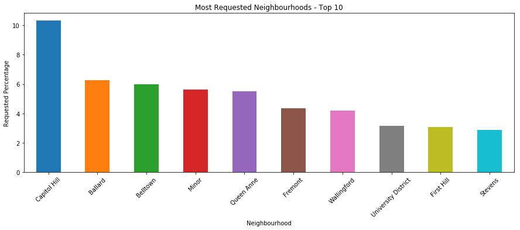

```python
plt.figure(figsize=(15,5));
neighbourhood_requests['percentage'][:10].plot(kind='bar', legend=False);
plt.xlabel('Neighbourhood');
plt.ylabel('Requested Percentage');
plt.title('Most Requested Neighbourhoods - Top 10');
plt.xticks(rotation=45);
plt.show();
```